### Homework 1 Key

#### PS 452: Text as Data

#### Fall 2014

**Question 1. Using Python**

See hw1_key.py

**Question 2. Properties of Random Variables**

1. Suppose $X$ is a random variable, with $E[X] = \mu$ and var$(X) = \sigma^2$. Show that $c = E[X]$ minimizes

$\begin{eqnarray} E[ (X - c)^2] \nonumber \end{eqnarray}$ Why does this suggest $E[X]$ is a ``good" guess for the value of $X$?

**Answer:** $\begin{eqnarray} E[ (X - c)^2] & = & E[X^2] - 2 c E[X] + E[c^2] \nonumber \\ & = & E[X^2] - 2 cE[X] + c^2 \nonumber \\ \frac{\partial E[ (X - c)^2]}{\partial c} & = & - 2 E[X] + 2 c \nonumber \\ 0 & = & - 2 E[X] + 2 c^{*} \nonumber \\ E[X] & = & c^{*} \nonumber \end{eqnarray}$

It suggests that the $E[X]$ is the value of $c$ that minimizes the average squared distance.

2. Suppose $Y$ and $Z$ are random variables, with joint density $f(y, z)$.
   1. How do we obtain the marginal distribution of $Y$, $f_{Y}(y)$ (should be an expression involving an integral)?

   **Answer** $\begin{eqnarray} f_{Y}(y) & = & \int_{-\infty}^{\infty} f(y, z) dz \nonumber \end{eqnarray}$
   2. How do we obtain the marginal distribution of $Z$, $f_{Z}(z)$ (should be an expression involving an integral)?

   **Answer** $\begin{eqnarray} f_{Z}(z) & = & \int_{-\infty}^{\infty} f(y, z) dy \nonumber \end{eqnarray}$
   3. Show that if $Y$ and $Z$ are independent, $E[YZ] = E[Y]E[Z]$.

   **Answer** $\begin{eqnarray} E[YZ] & = & \int_{-\infty}^{\infty}\int_{-\infty}^{\infty} YZ f(y, z) dydz \nonumber \\ & = & \int_{-\infty}^{\infty}\int_{-\infty}^{\infty} YZ f_{Y}(y) f_{Z}(z) dy dz \nonumber \\ & = & \int_{-\infty}^{\infty} Y f_{Y}(y)dy \int_{-\infty}^{\infty} f_{Z}(z) dz \nonumber \\ & = & E[Y] E[Z] \nonumber \end{eqnarray}$

**Question 3: Finding Critical Values for a Function**

Suppose we have a function $f:\Re\rightarrow\Re$, $f(x) = \sin(x)$.

1. Using `R` plot $\sin(x)$ for $x \in [-2 \pi, 2 \pi]$ (here $\pi$ is the mathematical constant).

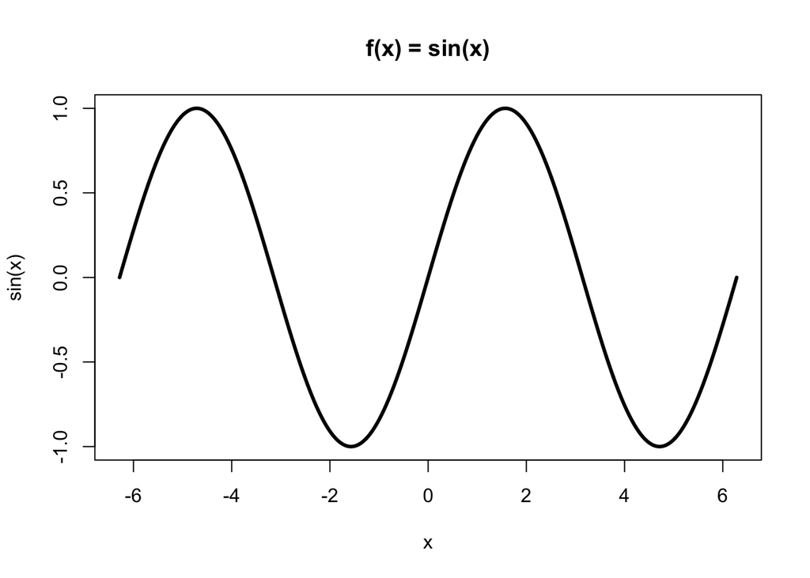

```r
xx<- seq(-2*pi, 2*pi, len = 1000)
plot(sin(xx)~xx, type='l', lwd = 3, xlab = 'x', ylab = 'sin(x)', main= "f(x) = sin(x)")
```

2. What is $f^{'}(x)$ (first derivative at $x$)? Using `R` plot it over $[-2 \pi, 2 \pi]$

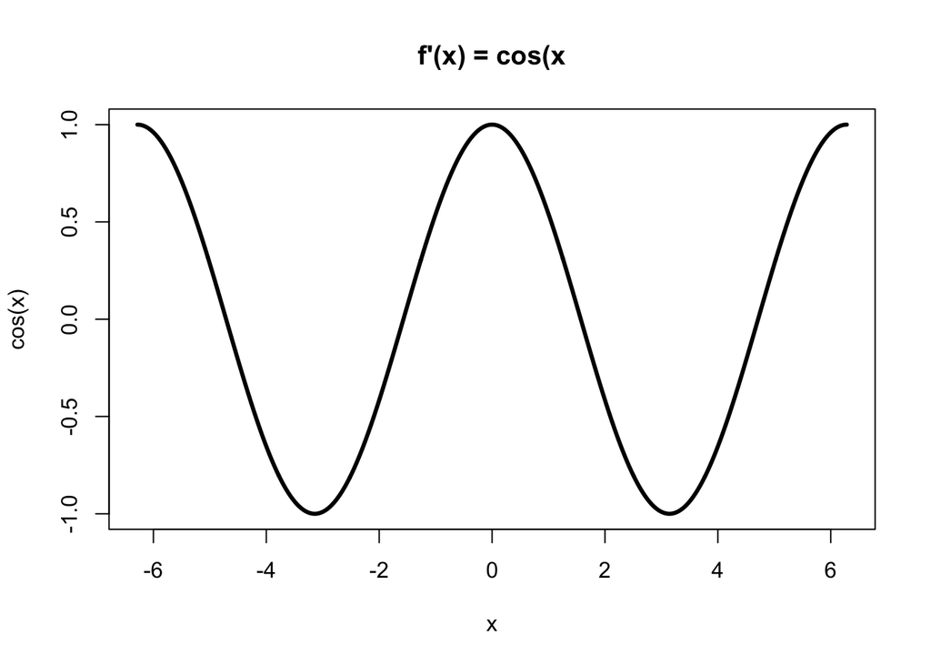

```r
plot(cos(xx)~xx, type='l', lwd = 3, xlab = 'x', ylab = 'cos(x)', main= "f'(x) = cos(x")
```

3. What is $f^{''}(x)$ (second derivative at $x$)? Using `R` plot it over $[-2 \pi, 2 \pi]$

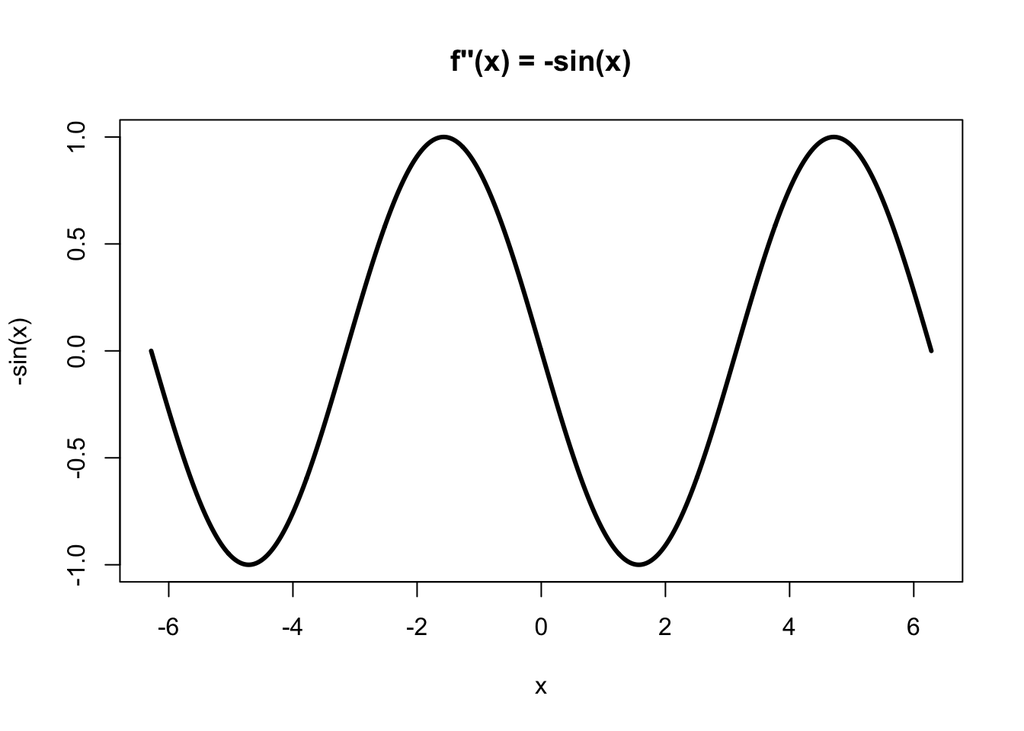

```r
plot(I(-sin(xx))~xx, type='l', lwd = 3, xlab = 'x', ylab = '-sin(x)', main= "f''(x) = -sin(x)")
```

We say that $x^{*}$ is a critical value for a function if $f^{'}(x^{*}) = 0$. We can find $x^{*}$ algebraically. Or, we can use a computational approach.\ We discussed the Newton-Raphson approach in class on Thursday. We’re going to write our own implementation of the algorithm in `R` and apply it to find the critical values of $f(x) = \sin(x)$

4. Suppose that we have current guess for the root $x_{t}$. Then the updated guess, $x_{t+1}$ is given by $\begin{eqnarray} x_{t+1} & = & x_{t} - \frac{f^{'}(x_{t})}{f^{''}(x_{t})} \end{eqnarray}$

where $f^{'}(x_{t})$ is the first derivative evaluated at $x_{t}$ and $f^{''}(x_{t})$ is the second derivative evaluated at $x_{t}$.

Write a function in `R` that provides the update step for some value $x_{t}$ if $f(x) = \sin(x)$.

```r
  up_newt<- function(x){
        x.1<- x + cos(x)/sin(x)
        return(x.1)
  }
```

5. The Newton-Raphson algorithm continues to update until the size of the update step drops below a threshold. Using the `while` command in R, write a loop that continues updating until the change,( $|x_{t+1} - x_{t}|$) drops below $10^{-5}$.

```r
    while(diff>tol){
            x<- x.1
            x.1<- up_newt(x)
            diff<- abs(x.1 - x)
    }
```

6. Place the while loop in a function that returns the converged value $x_{\text{final}}$

```r
  newt_raph<- function(x, tol){
        x.1<- up_newt(x)
        diff<- abs(x.1 - x)
        while(diff>tol){
            x<- x.1
            x.1<- up_newt(x)
            diff<- abs(x.1 - x)
        }
        return(x.1)
    }
```

7. Use your function with initial guesses $-2, -1, 1, 2$. What values do you obtain? Now examine the behavior close to $0$. Why is it so unstable?

```r
  guesses = c(-2,-1,1,2)
  for (i in guesses ){
        print(newt_raph(i, 10^-5))
  }
```

```
## [1] -1.571
## [1] -1.571
## [1] 1.571
## [1] 1.571
```

The algorithm is unstable because sin(0) = 0 . The result is that small differences in starting values are causing very big differences in the first step of the algorithm.

**Problem 3: Probit Regression with a Prior**

Suppose that we assume the following data generation process $\begin{eqnarray} Y_{i} & \sim & \text{Bernoulli}(\pi_{i} ) \nonumber \\ \pi_{i} & = & \Phi(\boldsymbol{X}_{i} \boldsymbol{\beta}) \nonumber \\ \beta_{j} & \sim & \text{Normal}(\mu, \sigma^{2}_{j} )\nonumber \end{eqnarray}$ with $\boldsymbol{X}_{i} = (1, x_{i})$ for all $i$ $(i = 1, ..., N)$, $\boldsymbol{\beta} = (\beta_{1}, \beta_{2})$, and $\Phi(\cdot)$ is the cumulative normal distribution function.

This is very similar to the model described in class, but now we have added a *prior* on $\boldsymbol{\beta}$. This slightly alters the objective function: $\begin{eqnarray} p(\boldsymbol{\beta} | \boldsymbol{Y}, \boldsymbol{X}) & \propto & p(\boldsymbol{\beta}|\mu, \sigma^2) \times p(\boldsymbol{Y}| \boldsymbol{X}, \boldsymbol{\beta}) \label{e:post} \\ & \propto & \prod_{j=1}^{2} \frac{1}{\sqrt{2\pi} \sigma} \exp\left( - \frac{(\beta_{j} - \mu )^2}{2 \sigma^2} \right) \times \prod_{i=1}^{N} \Phi(\boldsymbol{X}_{i}\boldsymbol{\beta})^{Y_{i} } ( 1- \Phi(\boldsymbol{X}_{i}\boldsymbol{\beta})^{1 - Y_{i} } \nonumber \end{eqnarray}$

In this problem, we will examine how the prior on $\boldsymbol{\beta}$, and in particular the values we set for $\mu$ and $\sigma^2$, alters our inferences about $\boldsymbol{\beta}$.

1. Analytically, write out the $\log(p(\boldsymbol{\beta} | \boldsymbol{Y}, \boldsymbol{X}))$.  
   **Answer** $\begin{eqnarray} \log p(\boldsymbol{\beta}| \boldsymbol{Y}, \boldsymbol{X}) & = & \sum_{j=1}^{2} \left(- \log \sigma + \frac{- (\beta_{j} - \mu)^{2}}{2 \sigma^2} \right) + \sum_{i=1}^{N} Y_{i} \log \Phi(\boldsymbol{X}_{i} \boldsymbol{\beta}) + (1- Y_{i}) \log \left( 1 - \Phi(\boldsymbol{X}_{i} \boldsymbol{\beta}) \right) + c \nonumber \end{eqnarray}$
2. In `R` create a function for the $\log$ of Equation 1.

```r
    log.post<- function(pars, mu, sig.2, Y, X){
        beta<- pars[1:2]
        part1<- dnorm(beta, mean = mu, sd = sqrt(sig.2), log = T)
        part2<- X%*%beta
        probs<- pnorm(part2)
        combine<- log(probs)*Y + log(1- probs)*(1-Y)
        out<- sum(part1) + sum(combine)
        return(out)
    }
```

3. Using the synthetic data and the optim guide from class, use `optim` to find $\widehat{\boldsymbol{\beta}}$ with $\mu = 0$ and $\sigma^2 = 1000$

```r
  data_set<- read.delim('~/Dropbox/TextAsData/ProblemSets/PS1/DataSet.csv', sep=',')

  data_set<- as.matrix(data_set)
  Y<- data_set[,1]
  X<- data_set[,-1]

  max.output<- optim(c(1, 1), log.post, method = 'BFGS', control = list(trace =100, fnscale = -1), hessian = T,  X = X, Y = Y , mu = 0, sig.2 = 1000)
  max.output
```

```
## $par
## [1]  0.8724 -1.3899
##
## $value
## [1] -194.4
##
## $counts
## function gradient
##       34       10
##
## $convergence
## [1] 0
##
## $message
## NULL
##
## $hessian
##         [,1]   [,2]
## [1,] -181.75 -70.77
## [2,]  -70.77 -97.58
```

4. Set $\mu = 1$ and then vary $\sigma^2$. Using a `for` loop, store estimates of how $\beta_{2}$ changes as you vary $\sigma^2$ from $10$ to $0.01$. Plot $\beta_{2}$ against $\sigma^2$ and describe what happens as $\sigma^2$ varies.

```r
  sigma.2.seq<- seq(0.01, 10, len = 1000)
  store.est<- c()

  for(z in 1:length(sigma.2.seq)){
        temp<- optim(c(1, 1), log.post, method = 'BFGS', control = list(trace =100, fnscale = -1), hessian = T,  X = X, Y = Y , mu = 1, sig.2 = sigma.2.seq[z])
        store.est[z]<- temp$par[2]
}
  #output surpressed
```

As $\sigma^2 \rightarrow$, the ``prior" becomes more informative and affects the inference more.

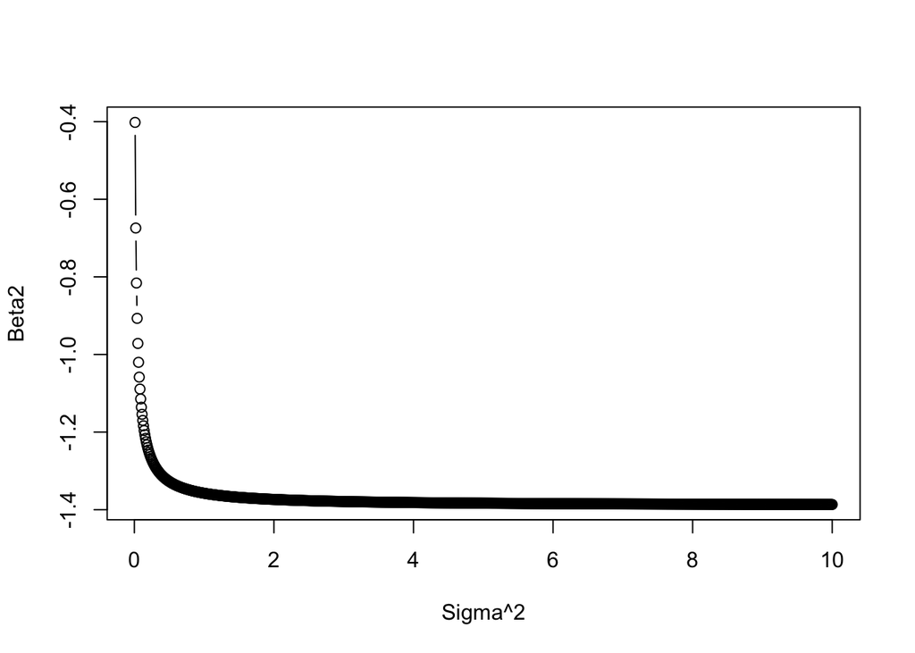

```r
  plot(store.est~sigma.2.seq, type='b', xlab = 'Sigma^2', ylab = 'Beta2')
```